# CombinedDataScienceLabFinal

```python
# How to print in Python
print("Hello, World!")
x = 5
y = "John"
print(x)
print(y)

name = ""

print("My name is  "+ name)
```

```
Hello, World!
5
John
My name is
```

```python
# How to define a function , how to do user input from the keyboard, and how to call the user defined function
# How to use "for loop".
# This user defined function counts all the "p" letters in the string input by user
def count_s(word):
  count = 0
  for letter in word:
    if ((letter == "p") |(letter == "P")):
      count = count+1
  return count
str = input("Enter the string\n") ## for keyboard input
print(count_s(str))
```

```
Enter the string
Pumpkin
2
```

# How to print multiple variables in Python

```python
#Print multiple variables in Python THERE ARE MAIN FOUR METHODS

##  Method 1: Passing multiple variables as arguments separating them by commas
# Syntax : print(variable1, varaible2, variable3, ...)

name = "Mike"
age = 21
country = "USA"
print(name, age, country)  # print() prints a new line
```

```
Mike 21 USA
```

```python
## Method 2: Using format() method with curly braces ({})
# Syntax: print("{} {} {}".format(variable1, variable2, variable2)

name = "Mike"
age = 21
country = "USA"

print("{} {} {}".format(name, age, country))
print("Name: {}, Age: {}, Country: {}".format(name, age, country))
```

```
Mike 21 USA
Name: Mike, Age: 21, Country: USA
```

```python
## Method 3: Using format() method with numbers in curly braces ({0})
# Syntax:  print("{0} {1} {2}".format(variable1, variable2, variable2)

#  Note: Number 0 represents the first variable in format() method, 1 represents the second, and so on.
## This is similar to method 2 but here we can use the numbers inside the curly braces ({0}),
#   it will help for reordering the values.

name = "Mike"
age = 21
country = "USA"

print("{0} {1} {2}".format(name, age, country))
print("Name: {0}, Age: {1}, Country: {2}".format(name, age, country))

print("Country: {2}, Name: {0}, Age: {1}".format(name, age, country))

# printing all values 2-2 times
print("{0} {0} {1} {1} {2} {2}".format(name, age, country))
```

```
Mike 21 USA
Name: Mike, Age: 21, Country: USA
Country: USA, Name: Mike, Age: 21
Mike Mike 21 21 USA USA
```

```python
## Method 4: Using format() method with explicit name in curly braces ({v})

 #Syntax:  print("{v1} {v2} {v3}".format(v1=variable1, v2=variable2, v3=variable2)


name = "Mike"
age = 21
country = "USA"

print("{n} {a} {c}".format(n=name, a=age, c=country))
print("Name: {n}, Age: {a}, Country: {c}".format(n=name, a=age, c=country))

print("Country: {c}, Name: {n}, Age: {a}".format(n=name, a=age, c=country))

# printing all values 2-2 times
print("{n} {n} {a} {a} {c} {c}".format(n=name, a=age, c=country))
```

```
Mike 21 USA
Name: Mike, Age: 21, Country: USA
Country: USA, Name: Mike, Age: 21
Mike Mike 21 21 USA USA
```

```python
## Method 5: Using string concatenation
## We can print multiple variables by concatenating them as a string.

#Syntax: print(str(variable1) + str(variable2) + str(variable3))
#Note: If we want to display any message or separator, we can also concatenate them with the variables.
##     If a variable is a string, then there is no need to use str().


name = "Mike"
country = "USA"

print("Without separator...")
print(name  + country)

print("Separating by commas...")
print(name +  "," + country)
print("Printing with messages...")

print("Name: " + name + " Country: " + country)
```

```
Without separator...
MikeUSA
Separating by commas...
Mike,USA
Printing with messages...
Name: Mike Country: USA
```

```python
#Method 6: Using print(f"LabelName: {variable:.6f}")- at 0.6 level meaning 6 digit after decimal points
##Eg;
myValue = 12.987645321211
print(f"Value: {myValue:.3f}")
```

```
Value: 12.988
```

```python
###        numpy.random.uniform(low=0.0, high=1.0, size=None)
##        Draw samples from a uniform distribution.
##       Samples are uniformly distributed over the half-open interval [low, high)
##       (includes low, but excludes high).
##        In other words, any value within the given interval is equally likely to be drawn by uniform

### Generating uniform distribution data using numpy.random.uniform method
import numpy

import matplotlib.pyplot as plt    ## For data visualising purpose we import matplotlib.pyplot

from scipy import stats # For creating and fitting  linear regression model




#Generating uniform distribution  data
x = numpy.random.uniform(0.0, 5.0, 250)  ## low = 0,0, high = 5.0, size = 250
print(x)
print(type(x))
```

```
[1.74827563 0.5106782  4.90914328 1.36354693 1.17258685 3.51100287
 1.32069067 4.75918755 2.98258426 3.243775   1.14375154 4.9649192
 3.02113357 4.72832261 0.46148938 1.82950461 4.7276312  4.72582435
 2.72736113 4.46780867 4.41663893 1.65579555 0.52232365 0.8789071
 0.49557339 3.85556333 2.51158169 4.22677474 4.79630184 3.68558059
 3.67131698 3.758669   3.66524562 2.74030368 0.37137235 0.5229804
 3.06573093 0.26491138 4.58920319 1.03411027 3.42939955 4.41021622
 4.16598725 1.27722497 0.24838214 3.17938436 4.13502007 3.53579817
 1.67556964 2.04721754 2.1261484  3.09424776 2.13771097 0.93511937
 3.62472929 1.16422054 1.49888357 1.45552081 1.27926662 0.42986754
 0.63850962 1.83783837 3.61773263 0.65109944 2.63122893 3.91292371
 4.87226435 3.04512599 0.42155795 1.86750804 0.46078981 0.75275072
 1.80884423 4.54979588 3.92116326 3.97643051 3.52880136 1.25693486
 0.950358   1.39511211 3.53770375 0.60796634 2.34747923 3.9998432
 0.65797761 4.13953363 0.35049394 4.46409559 0.4456583  1.86168765
 1.98419605 3.81829166 0.71660382 4.43651177 4.70248697 1.33978654
 3.7407628  2.43586128 1.39309235 2.71210991 0.54649738 2.26268414
 3.87545129 0.71894107 3.78478126 0.05432154 3.69604563 2.0177526
 3.85262966 2.63889029 3.35415122 1.54091559 1.77715756 4.79301514
 2.3753259  3.19202449 4.05763861 4.90241274 3.49633599 0.56927319
 4.16638978 2.11753737 4.06788005 2.31021712 1.62379918 2.04369978
 3.24747199 2.12877329 4.1263897  2.34563732 0.6099115  4.73553234
 4.17310362 3.28409148 4.67564228 2.32175951 3.2387083  4.44026057
 4.34415994 1.47130862 0.74525579 2.52005398 4.74199628 2.4593921
 3.90205729 0.05522489 0.91931225 3.11464776 1.77762598 1.57813542
 3.12579139 0.20556656 4.70477948 4.13220892 0.12628741 1.91052687
 0.75405843 0.51465682 1.61368163 0.35480403 1.68083648 3.95997196
 2.61963357 3.30658346 3.73966033 0.84372336 0.17781085 0.27123936
 3.75378595 2.54447452 4.88659257 4.06778641 2.09984822 1.73778281
 3.86785397 0.46699884 1.31011353 3.74530528 1.0509433  4.62475976
 1.44036939 4.31926187 1.5671774  0.45121488 2.5801689  3.94591616
 4.9393546  0.63386229 2.35822046 3.26917226 3.30094962 1.65480272
 4.79423567 3.84184265 2.1110521  4.67320807 2.85418077 3.82612798
 2.09769259 1.97892874 0.29475598 2.73965204 0.23894354 4.63581446
 2.37395947 1.27577133 4.48663031 2.27581852 3.42908937 0.54130092
 2.38737754 4.38335097 4.82338145 3.48710231 4.78425679 1.5572374
 3.59977923 0.40174722 4.92728451 1.87027676 4.03576917 3.00331431
 0.51520022 3.33351565 4.19967067 2.18783081 4.03394408 3.93890023
 2.23663948 1.72362641 2.97299738 3.71051377 2.45291063 0.63577017
 0.60243742 3.32484166 3.03298495 3.12316724 3.94556978 1.52995161
 2.9155104  1.40154915 3.55825878 4.72806402 1.18356947 0.12681971
 0.14920298 1.57001002 2.39425953 2.00867404]
<class 'numpy.ndarray'>
```

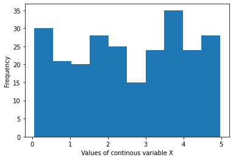

```python
#print a histogram from the data. Histograms are usually used when visualizing a dataset of continuous variables.

plt.hist(x,10) # here, X along x-axis is continous data, 10 is total number of bins(bars)[ Bars are small continous interval],
#  y-axis is frequency of data in x=axis
plt.xlabel("Values of continous variable X")
plt.ylabel("Frequency")

plt.show()
```

```python
 ## numpy.random.normal(loc, scale, size) Loc= mean of the distribution(by default=0),
    ## scale = the standard deviation of the normal distribution,
    # size = The size parameter controls the size and shape of the output. Output is a NumPy array

x = numpy.random.normal(5.0, 1.0, 100000) #Randomly selected normal distribution(AKA, Bell shape)
                                          # with 100000 values,mean value 5 and standard deviation of 1.
                                           # x output is a NumPy array
```

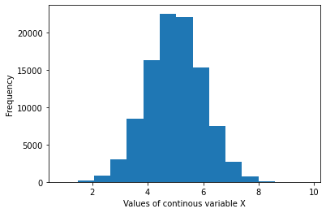

```python
#print a histogram from the normal distribution data. Histograms are usually used when visualizing a dataset of continuous variables.

plt.hist(x,15) # here, X along x-axis is continous data, 15 is total number of bins(bars)[ Bars are small continous interval],
#  y-axis is frequency of data in x=axis
plt.xlabel("Values of continous variable X")
plt.ylabel("Frequency")

plt.show()
```

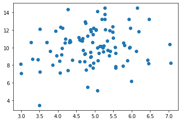

```
<class 'numpy.ndarray'>
```

```python
# Generating  and plotting a scatter  for x and y NumPy arrays values

import numpy

import matplotlib.pyplot as plt

x = numpy.random.normal(5.0, 1.0, 100) # Normal distribution: 100 values mean value 5 and stdDev 1

y = numpy.random.normal(10.0, 2.0, 100) # Normal distribution: 100 values mean value 10 and stdDev 2

plt.scatter(x,y)

plt.show()
print(type(x))
```

# Difference Between List and Array in Python

```python
# Difference Between List and Array in Python

""""                                Difference Between List and Array in Python

S.No.                        List                                                                      Array
1  List is used to collect items that usually consist of elements of multiple data types       An array is also a vital component that collects  several items of the same data type.
2  List cannot manage arithmetic operations.                                                   Array can manage arithmetic operations.
3  It consists of elements that belong to the different data types.                            It consists of elements that belong to the same data type.
4  When it comes to flexibility, the list is perfect as it allows easy modification of data.   When it comes to flexibility, the array is not suitable as it does not allow easy modification of data.
5  It consumes a larger memory.                                                                 It consumes less memory than a  list.
6  In a list, the complete list can be accessed without any specific looping.                  In an array, a loop is mandatory to access the components of the array.
7  It favors a shorter sequence of data.                                                        It favors a longer sequence of data."""
```

```python
## How to comment in python
## Single line comment: Need to add a # before a line to mark it as a comment line
##  Multiline comments: For a multiline comment, Need to start and end it with """.
## Eg.For multiple lines

"""   Python Collections (Arrays)
There are four collection data types in the Python programming language:

List  is a collection which is ordered and changeable. Allows duplicate members.
Tuple is a collection which is ordered and unchangeable. Allows duplicate members.
Set is a collection which is unordered, unchangeable*, and unindexed. No duplicate members.
Dictionary is a collection which is ordered** and changeable. No duplicate members.  """
```

```
'   Python Collections (Arrays)\nThere are four collection data types in the Python programming language:\n\nList  is a collection which is ordered and changeable. Allows duplicate members.\nTuple is a collection which is ordered and unchangeable. Allows duplicate members.\nSet is a collection which…
```

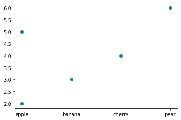

```python
### Single line comments Eg.:

# List :Lists are used to store multiple items in a single variable.
#Lists are one of 4 built-in data types in Python used to store collections of data,
# the other 3 are Tuple, Set, and Dictionary, all with different qualities and usage.
# List items are ordered, changeable(or mutable), and allow duplicate values, with zer0-indexed(meaning-first index is zero)
# List items can be of any data types:
# Lists are created using square brackets:
# Eg.:
list1 = ["apple", "banana", "cherry", "apple", "pear"]
list2 = ["apple", "banana", "cherry"]
list3 = ["abc", "dog", "True", "female", "male"]
list4 = [2,3,4,5,6]


x = [5,7,8,7,2,17,2,9,4,11,12,9,6] # Defining a list and assigning values

y = [99,86,87,88,111,86,103,87,94,78,77,85,86]



#A scatter plot of two lists

plt.scatter(list1, list4)

plt.show()
```

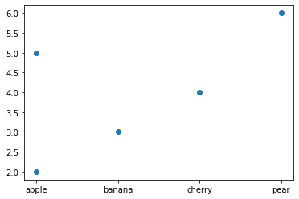

```python
#A scatter plot of two lists
x = [5,7,8,7,2,17,2,9,4,11,12,9,6] # Defining a list and assigning values

y = [99,86,87,88,111,86,103,87,94,78,77,85,86]
plt.scatter(list1, list4)

plt.show()
```

# np.random.normal() versus np.random.randn()

# The major difference is that

np.random.randn is like a special case of np.random.normal. np.random.randn operates like np.random.normal with loc = 0 and scale = 1.

So, np.random.randn( 50) = np.ramdom.normal(loc= 0, scale = 1, size = 50) . Mean= 0, stdv= 1, size = 50

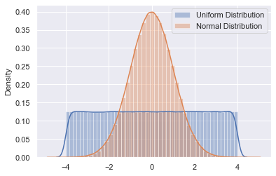

```python
# Imports
import numpy as np
import matplotlib.pyplot as plt
import seaborn as sns        ## seaborn is developed verson of matplotlib for visualization
sns.set()
import warnings
warnings.simplefilter("ignore", UserWarning)

# Let's create an array of random numbers from uniform distribution
uniform = np.random.uniform(-4,4,1000000)

# Let's create an array of random numbers from normal distribution
normal = np.random.randn(1000000) # This is same as normal - np.random.normal(0,1,1000000)
normal1 = np.random.normal(0,1,1000000)

# Let's plot them
ax = sns.distplot(uniform, label='Uniform Distribution')
bx = sns.distplot(normal, label= 'Normal Distribution')
legend = plt.legend()
plt.show()
```

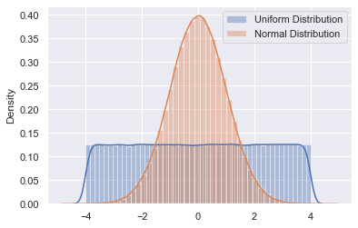

```python
# Let's create an array of random numbers from uniform distribution
uniform = np.random.uniform(-4,4,1000000)

# Let's create an array of random numbers from normal distribution
normal1 = np.random.normal(0,1,1000000) ## This is same as normal - np.random.randn(1000000)
# Let's plot them
ax = sns.distplot(uniform, label='Uniform Distribution')
bx = sns.distplot(normal1, label= 'Normal Distribution')
legend = plt.legend()
plt.show()
```

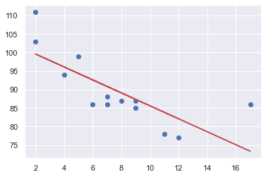

```
r: -0.758591524376155
p:  0.0026468739224561064
std:  0.45353615760774213
Slope:  -1.751287711552612
intercept:  103.10596026490066
[5, 7, 8, 7, 2, 17, 2, 9, 4, 11, 12, 9, 6]
[99, 86, 87, 88, 111, 86, 103, 87, 94, 78, 77, 85, 86]
94.3495
90.8469
89.0957
90.8469
99.6034
73.3341
99.6034
87.3444
96.1008
83.8418
82.0905
87.3444
92.5982
<class 'list'>
```

```python
## Creating and fitting a linear regression model using two lists of numerical data

import numpy

import matplotlib.pyplot as plt

from scipy import stats



x = [5,7,8,7,2,17,2,9,4,11,12,9,6] # List

y = [99,86,87,88,111,86,103,87,94,78,77,85,86]  #list



#   stats.linregress(x, y)     #method returns some important key values of Linear Regression as seen below

slope, intercept, r, p, std_err = stats.linregress(x, y)

def myfunc(x):                                  # python’s anonymous function...

  return slope * x + intercept

map_object = (map(myfunc, x)) # map() function returns a map object (AKA iterator) of the results after it applying the
mymodel = list(map_object)    # function parameter 'myfun()'' to each item of the iterable parameter like list, tuple, etc.
                               # syntax: map(function, iterator)
                               # list(map_object) converst map object to list of item
                               # So, mym odel is now predicted values or modal values for x list or x predictors

plt.scatter(x, y)                 #Draw the original scatter plot

plt.plot(x, mymodel, 'r')                 # Draw the line of linear regression model in color red.'r' indicates red
                                          # 'b' indicates blue

#stats.linregress(x, y)

plt.show()                           #Display the diagram:

print('r:', r) # this value to indicate strength of the correlation. (0-1 +ve relationship 0r 0-1 -ve relationship)
print('p: ',p)
print("std: ",std_err)
print("Slope: ", slope)
print("intercept: ",intercept)
print(x)
print(y)
#print(mymodel)
for m in mymodel:
  print("%.4f " %m)
print(type(x))
```

```python
## Fitting a simple linear regression model using "Study hours" as predictor and "Exam score" as response variable.
import numpy as np

import matplotlib.pyplot as plt

from scipy import stats as st
```

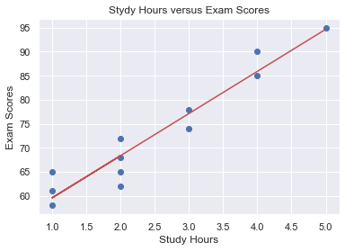

```python
x = [1,1,2,2,1,2,2,3,3,4,4,5] #List of Study hours

y = [58,61,62,65,65,68,72,74,78,85,90,95]  #List of  Exam scores
# Fitting the model
slope, intercept, r, p, std_err = st.linregress(x,y)
def createModel(x):                  # defining a python function for creating model
    respondedVar = slope*x+intercept
    return respondedVar
model = map(createModel,x) # Creating a model object as a map object
listModel = list(model) # Creating a list from map object "model"
plt.plot(x,listModel,'r')
plt.scatter(x,y) # Scatter graph
plt.title("Stydy Hours versus Exam Scores")
plt.xlabel("Study Hours")
plt.ylabel("Exam Scores")
plt.show()
```

```python
print(r) # Relationship strenth, thst is correlation beteween study hours and exam scores
print(p)
type(model)
```

```
0.9590729006011031
8.442058036727867e-07
```

```
map
```

## Here, correlation between study hours and exam scores (r) is 0.959, which is greater than 0.5. So, r>0.5 is a strong correlation . So, the professor can confidently use this relationship to predict exam scores for his/her students given the student's study hours.

```python
# Reading csv file into google colab
""""
import pandas as pd
import io
from google.colab import files
uploaded = files.upload()
df = pd.read_csv(io.BytesIO(uploaded['testDataset.csv'])) # storing data into Pandas Dataframe
"""
```

```
'"\nimport pandas as pd\nimport io\nfrom google.colab import files\nuploaded = files.upload()\ndf = pd.read_csv(io.BytesIO(uploaded[\'testDataset.csv\'])) # storing data into Pandas Dataframe\n'
```

```python
## Reading data into dataframe in Jupyter notebook (That is .csv file)
import pandas as pd
import matplotlib.pyplot as plt
import numpy as np
```

```python
df1 = pd.read_csv('testDataset.csv')  ## Reading data into dataframe in Jupyter notebook (That is .csv file)
```

```python
# Shape of dataframe( That is, total number of rows and column)
df1.shape
```

```
(24, 16)
```

```python
 df1.head() # First five rows of data
```

|  | iso_code | continent | location | date | total_cases | new_cases | new_cases_smoothed | total_deaths | new_deaths | new_deaths_smoothed | total_cases_per_million | new_cases_per_million | new_cases_smoothed_per_million | total_deaths_per_million | new_deaths_per_million | new_deaths_smoothed_per_million |
| --- | --- | --- | --- | --- | --- | --- | --- | --- | --- | --- | --- | --- | --- | --- | --- | --- |
| 0 | USA | North America | United States | 3/5/2020 | 184 | 77 | 23.857 | 12 | 1 | 1.714 | 0.556 | 0.233 | 0.072 | 0.036 | 0.003 | 0.005 |
| 1 | USA | North America | United States | 3/6/2020 | 237 | 53 | 31.429 | 14 | 2 | 2.000 | 0.716 | 0.160 | 0.095 | 0.042 | 0.006 | 0.006 |
| 2 | USA | North America | United States | 3/7/2020 | 403 | 166 | 54.000 | 17 | 3 | 2.286 | 1.218 | 0.502 | 0.163 | 0.051 | 0.009 | 0.007 |
| 3 | USA | North America | United States | 3/8/2020 | 519 | 116 | 69.571 | 21 | 4 | 2.857 | 1.568 | 0.350 | 0.210 | 0.063 | 0.012 | 0.009 |
| 4 | USA | North America | United States | 3/9/2020 | 594 | 75 | 77.000 | 22 | 1 | 2.286 | 1.795 | 0.227 | 0.233 | 0.066 | 0.003 | 0.007 |

```python
df1.tail()# Last five rows of data
```

|  | iso_code | continent | location | date | total_cases | new_cases | new_cases_smoothed | total_deaths | new_deaths | new_deaths_smoothed | total_cases_per_million | new_cases_per_million | new_cases_smoothed_per_million | total_deaths_per_million | new_deaths_per_million | new_deaths_smoothed_per_million |
| --- | --- | --- | --- | --- | --- | --- | --- | --- | --- | --- | --- | --- | --- | --- | --- | --- |
| 19 | USA | North America | United States | 3/24/2020 | 56755 | 10619 | 7177.571 | 1033 | 241 | 128.429 | 171.464 | 32.081 | 21.684 | 3.121 | 0.728 | 0.388 |
| 20 | USA | North America | United States | 3/25/2020 | 68837 | 12082 | 8524.000 | 1369 | 336 | 167.857 | 207.965 | 36.501 | 25.752 | 4.136 | 1.015 | 0.507 |
| 21 | USA | North America | United States | 3/26/2020 | 86693 | 17856 | 10432.857 | 1785 | 416 | 217.000 | 261.910 | 53.945 | 31.519 | 5.393 | 1.257 | 0.656 |
| 22 | USA | North America | United States | 3/27/2020 | 105383 | 18690 | 12193.286 | 2311 | 526 | 277.000 | 318.375 | 56.465 | 36.837 | 6.982 | 1.589 | 0.837 |
| 23 | USA | North America | United States | 3/28/2020 | 125013 | 19630 | 14141.143 | 2985 | 674 | 358.571 | 377.680 | 59.305 | 42.722 | 9.018 | 2.036 | 1.083 |

```python
df1.info()# Exploring df1
```

```
<class 'pandas.core.frame.DataFrame'>
RangeIndex: 24 entries, 0 to 23
Data columns (total 16 columns):
 #   Column                           Non-Null Count  Dtype
---  ------                           --------------  -----
 0   iso_code                         24 non-null     object
 1   continent                        24 non-null     object
 2   location                         24 non-null     object
 3   date                             24 non-null     object
 4   total_cases                      24 non-null     int64
 5   new_cases                        24 non-null     int64
 6   new_cases_smoothed               24 non-null     float64
 7   total_deaths                     24 non-null     int64
 8   new_deaths                       24 non-null     int64
 9   new_deaths_smoothed              24 non-null     float64
 10  total_cases_per_million          24 non-null     float64
 11  new_cases_per_million            24 non-null     float64
 12  new_cases_smoothed_per_million   24 non-null     float64
 13  total_deaths_per_million         24 non-null     float64
 14  new_deaths_per_million           24 non-null     float64
 15  new_deaths_smoothed_per_million  24 non-null     float64
dtypes: float64(8), int64(4), object(4)
memory usage: 3.1+ KB
```

```python
# How to get rid of the following 6 columns

df2 = df1.drop( ["continent", "location", "date", "new_deaths", "new_deaths_smoothed", "new_deaths_per_million"], axis = 1)
df2   # New dataframe after dropping 6 columns
```

|  | iso_code | total_cases | new_cases | new_cases_smoothed | total_deaths | total_cases_per_million | new_cases_per_million | new_cases_smoothed_per_million | total_deaths_per_million | new_deaths_smoothed_per_million |
| --- | --- | --- | --- | --- | --- | --- | --- | --- | --- | --- |
| 0 | USA | 184 | 77 | 23.857 | 12 | 0.556 | 0.233 | 0.072 | 0.036 | 0.005 |
| 1 | USA | 237 | 53 | 31.429 | 14 | 0.716 | 0.160 | 0.095 | 0.042 | 0.006 |
| 2 | USA | 403 | 166 | 54.000 | 17 | 1.218 | 0.502 | 0.163 | 0.051 | 0.007 |
| 3 | USA | 519 | 116 | 69.571 | 21 | 1.568 | 0.350 | 0.210 | 0.063 | 0.009 |
| 4 | USA | 594 | 75 | 77.000 | 22 | 1.795 | 0.227 | 0.233 | 0.066 | 0.007 |
| 5 | USA | 782 | 188 | 101.143 | 28 | 2.363 | 0.568 | 0.306 | 0.085 | 0.009 |
| 6 | USA | 1147 | 365 | 148.571 | 33 | 3.465 | 1.103 | 0.449 | 0.100 | 0.009 |
| 7 | USA | 1586 | 439 | 200.286 | 43 | 4.792 | 1.326 | 0.605 | 0.130 | 0.013 |
| 8 | USA | 2219 | 633 | 283.143 | 51 | 6.704 | 1.912 | 0.855 | 0.154 | 0.016 |
| 9 | USA | 2978 | 759 | 367.857 | 58 | 8.997 | 2.293 | 1.111 | 0.175 | 0.018 |
| 10 | USA | 3212 | 234 | 384.714 | 70 | 9.704 | 0.707 | 1.162 | 0.211 | 0.021 |
| 11 | USA | 4679 | 1467 | 583.571 | 97 | 14.136 | 4.432 | 1.763 | 0.293 | 0.032 |
| 12 | USA | 6512 | 1833 | 818.571 | 134 | 19.674 | 5.538 | 2.473 | 0.405 | 0.046 |
| 13 | USA | 9169 | 2657 | 1146.000 | 194 | 27.701 | 8.027 | 3.462 | 0.586 | 0.069 |
| 14 | USA | 13663 | 4494 | 1725.286 | 266 | 41.278 | 13.577 | 5.212 | 0.804 | 0.096 |
| 15 | USA | 20030 | 6367 | 2544.429 | 372 | 60.513 | 19.235 | 7.687 | 1.124 | 0.139 |
| 16 | USA | 26025 | 5995 | 3292.429 | 475 | 78.625 | 18.112 | 9.947 | 1.435 | 0.180 |
| 17 | USA | 34898 | 8873 | 4526.571 | 603 | 105.431 | 26.806 | 13.675 | 1.822 | 0.230 |
| 18 | USA | 46136 | 11238 | 5922.429 | 792 | 139.383 | 33.951 | 17.892 | 2.393 | 0.300 |
| 19 | USA | 56755 | 10619 | 7177.571 | 1033 | 171.464 | 32.081 | 21.684 | 3.121 | 0.388 |
| 20 | USA | 68837 | 12082 | 8524.000 | 1369 | 207.965 | 36.501 | 25.752 | 4.136 | 0.507 |
| 21 | USA | 86693 | 17856 | 10432.857 | 1785 | 261.910 | 53.945 | 31.519 | 5.393 | 0.656 |
| 22 | USA | 105383 | 18690 | 12193.286 | 2311 | 318.375 | 56.465 | 36.837 | 6.982 | 0.837 |
| 23 | USA | 125013 | 19630 | 14141.143 | 2985 | 377.680 | 59.305 | 42.722 | 9.018 | 1.083 |

```python
df2.shape
```

```
(24, 10)
```

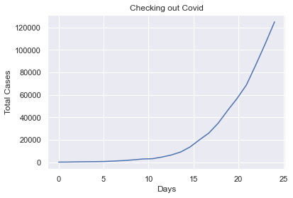

```python
#Lets visualize Total cases by Day:

plt.xlabel('Days')

plt.ylabel('Total Cases')

plt.rcParams["figure.figsize"] = [10,5]

plt.title('Checking out Covid')

x_vals = np.linspace(0, 24, 24)

plt.plot(x_vals,df2["total_cases"], 'b')
```

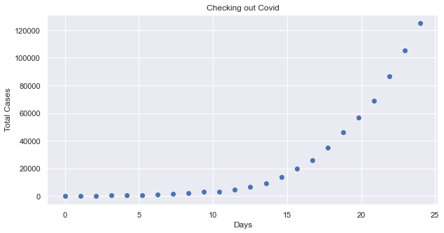

```python
#Lets visualize Total cases by Day:

plt.xlabel('Days')

plt.ylabel('Total Cases')

plt.rcParams["figure.figsize"] = [10,5]

plt.title('Checking out Covid')

x_vals = np.linspace(0, 24, 24)

plt.scatter(x_vals, df1["total_cases"], c='b')
```

```python
#Lets visualize  new deaths  by Day in a dataset finalDataset
df3 = pd.read_csv("finalDataset.csv")
```

```python
df3.shape
```

```
(486, 60)
```

```python
df3.info()
```

```
<class 'pandas.core.frame.DataFrame'>
RangeIndex: 486 entries, 0 to 485
Data columns (total 60 columns):
 #   Column                                 Non-Null Count  Dtype
---  ------                                 --------------  -----
 0   iso_code                               486 non-null    object
 1   continent                              486 non-null    object
 2   location                               486 non-null    object
 3   date                                   486 non-null    object
 4   total_cases                            486 non-null    int64
 5   new_cases                              486 non-null    int64
 6   new_cases_smoothed                     486 non-null    float64
 7   total_deaths                           486 non-null    int64
 8   new_deaths                             486 non-null    int64
 9   new_deaths_smoothed                    486 non-null    float64
```

[output cut: 52 more lines]

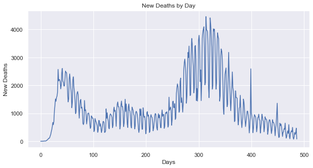

```python
## Visualizing  new deaths  by Day in a dataset finalDataset
plt.xlabel('Days')

plt.ylabel('New Deaths')

plt.rcParams["figure.figsize"] = [10,5]

plt.title('New Deaths by Day')

x_vals = np.linspace(0, 486, 486)

plt.plot(x_vals,df3["new_deaths"], 'b')
```

```python
## Now droping columns that are constants, null, and wit more than 30% data missing


df4 = df3.drop(["iso_code", "continent", "location", "weekly_icu_admissions",
                                  "weekly_icu_admissions_per_million", "weekly_hosp_admissions",
                                  "weekly_hosp_admissions_per_million", "tests_units", "excess_mortality",
                                  "handwashing_facilities", "population_density", "aged_65_older", "gdp_per_capita",
                                  "cardiovasc_death_rate", "diabetes_prevalence",  "hospital_beds_per_thousand",
                                  "life_expectancy", "human_development_index", "stringency_index", "population",
                                  "median_age",  "extreme_poverty"], axis = 1)
```

```python
df4.info()# Exploring data
```

```
<class 'pandas.core.frame.DataFrame'>
RangeIndex: 486 entries, 0 to 485
Data columns (total 38 columns):
 #   Column                                 Non-Null Count  Dtype
---  ------                                 --------------  -----
 0   date                                   486 non-null    object
 1   total_cases                            486 non-null    int64
 2   new_cases                              486 non-null    int64
 3   new_cases_smoothed                     486 non-null    float64
 4   total_deaths                           486 non-null    int64
 5   new_deaths                             486 non-null    int64
 6   new_deaths_smoothed                    486 non-null    float64
 7   total_cases_per_million                486 non-null    float64
 8   new_cases_per_million                  486 non-null    float64
 9   new_cases_smoothed_per_million         486 non-null    float64
```

[output cut: 30 more lines]

```python
df4
```

|  | date | total_cases | new_cases | new_cases_smoothed | total_deaths | new_deaths | new_deaths_smoothed | total_cases_per_million | new_cases_per_million | new_cases_smoothed_per_million | ... | people_fully_vaccinated | new_vaccinations | new_vaccinations_smoothed | total_vaccinations_per_hundred | people_vaccinated_per_hundred | people_fully_vaccinated_per_hundred | new_vaccinations_smoothed_per_million | aged_70_older | female_smokers | male_smokers |
| --- | --- | --- | --- | --- | --- | --- | --- | --- | --- | --- | --- | --- | --- | --- | --- | --- | --- | --- | --- | --- | --- |
| 0 | 3/5/2020 | 184 | 77 | 23.857 | 12 | 1 | 1.714 | 0.556 | 0.233 | 0.072 | ... | 0.0 | NaN | NaN | NaN | NaN | NaN | NaN | 9.732 | 19.1 | 24.6 |
| 1 | 3/6/2020 | 237 | 53 | 31.429 | 14 | 2 | 2.000 | 0.716 | 0.160 | 0.095 | ... | 0.0 | NaN | NaN | NaN | NaN | NaN | NaN | 9.732 | 19.1 | 24.6 |
| 2 | 3/7/2020 | 403 | 166 | 54.000 | 17 | 3 | 2.286 | 1.218 | 0.502 | 0.163 | ... | 0.0 | NaN | NaN | NaN | NaN | NaN | NaN | 9.732 | 19.1 | 24.6 |
| 3 | 3/8/2020 | 519 | 116 | 69.571 | 21 | 4 | 2.857 | 1.568 | 0.350 | 0.210 | ... | 0.0 | NaN | NaN | NaN | NaN | NaN | NaN | 9.732 | 19.1 | 24.6 |
| 4 | 3/9/2020 | 594 | 75 | 77.000 | 22 | 1 | 2.286 | 1.795 | 0.227 | 0.233 | ... | 0.0 | NaN | NaN | NaN | NaN | NaN | NaN | 9.732 | 19.1 | 24.6 |
| ... | ... | ... | ... | ... | ... | ... | ... | ... | ... | ... | ... | ... | ... | ... | ... | ... | ... | ... | ... | ... | ... |
| 481 | 6/29/2021 | 33651852 | 11350 | 12376.714 | 604395 | 314 | 271.143 | 101666.414 | 34.290 | 37.392 | ... | 154199664.0 | 738476.0 | 847000.0 | 97.22 | 53.80 | 46.11 | 2533.0 | 9.732 | 19.1 | 24.6 |
| 482 | 6/30/2021 | 33664970 | 13118 | 12474.143 | 604639 | 244 | 252.286 | 101706.045 | 39.631 | 37.686 | ... | 154884686.0 | 1368679.0 | 949925.0 | 97.63 | 54.02 | 46.31 | 2840.0 | 9.732 | 19.1 | 24.6 |
| 483 | 7/1/2021 | 33679433 | 14463 | 12707.429 | 604943 | 304 | 247.143 | 101749.739 | 43.695 | 38.391 | ... | 155884601.0 | 1630778.0 | 1066443.0 | 98.12 | 54.22 | 46.61 | 3189.0 | 9.732 | 19.1 | 24.6 |
| 484 | 7/2/2021 | 33709325 | 29892 | 13589.857 | 605413 | 470 | 243.286 | 101840.047 | 90.307 | 41.057 | ... | 156255896.0 | 657166.0 | 1087156.0 | 98.32 | 54.31 | 46.72 | 3251.0 | 9.732 | 19.1 | 24.6 |
| 485 | 7/3/2021 | 33714064 | 4739 | 13223.571 | 605493 | 80 | 233.714 | 101854.364 | 14.317 | 39.950 | ... | 156982549.0 | 1161081.0 | 1121064.0 | 98.66 | 54.45 | 46.94 | 3352.0 | 9.732 | 19.1 | 24.6 |

486 rows × 38 columns

```python
#3 Now visualizing fully vzccinated versus new deaths
df4["people_fully_vaccinated"].replace(np.nan, 0, inplace = True)     # Using numpy to replace all NAN values in
                                                                      # people_fully_vaccinated with zero
```

```python
df4.info() # Exploring after replacing all null values in people_fully_vaccinated with zero
```

```
<class 'pandas.core.frame.DataFrame'>
RangeIndex: 486 entries, 0 to 485
Data columns (total 38 columns):
 #   Column                                 Non-Null Count  Dtype
---  ------                                 --------------  -----
 0   date                                   486 non-null    object
 1   total_cases                            486 non-null    int64
 2   new_cases                              486 non-null    int64
 3   new_cases_smoothed                     486 non-null    float64
 4   total_deaths                           486 non-null    int64
 5   new_deaths                             486 non-null    int64
 6   new_deaths_smoothed                    486 non-null    float64
 7   total_cases_per_million                486 non-null    float64
 8   new_cases_per_million                  486 non-null    float64
 9   new_cases_smoothed_per_million         486 non-null    float64
```

[output cut: 30 more lines]

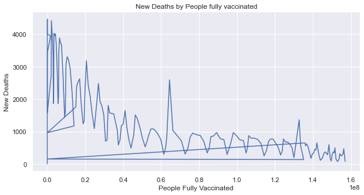

```python
#Let's visualize new deaths cases people_fully_vaccinated:

plt.xlabel('People Fully Vaccinated')

plt.ylabel('New Deaths')

plt.rcParams["figure.figsize"] = [10,5]

plt.title('New Deaths by People fully vaccinated')

plt.plot(df4["people_fully_vaccinated"],df4["new_deaths"], 'b')
```

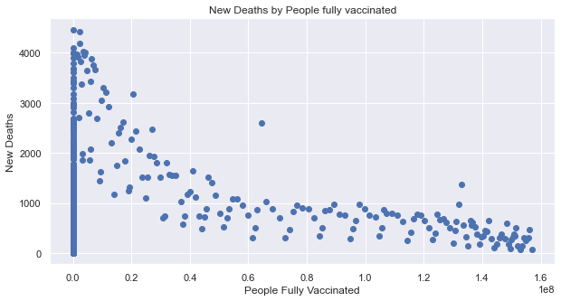

```python
##Let's visualize new deaths cases people_fully_vaccinated using scatter plot


plt.xlabel('People Fully Vaccinated')

plt.ylabel('New Deaths')

plt.rcParams["figure.figsize"] = [10,5]

plt.title('New Deaths by People fully vaccinated')

plt.scatter(df4["people_fully_vaccinated"], df4["new_deaths"], c='b')
```

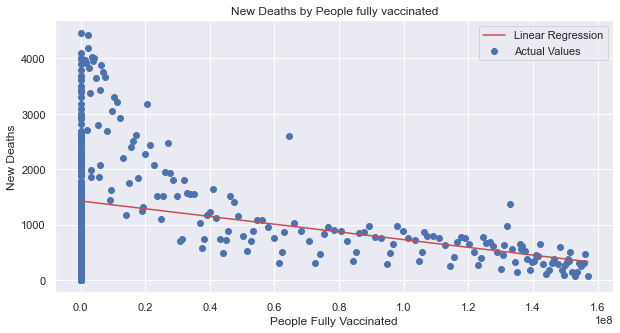

```
R-value: -0.345167
```

```python
## Now creating and fitting linear regression model for predicting new deaths based on people fully vaccinated


plt.xlabel('People Fully Vaccinated')

plt.ylabel('New Deaths')

plt.rcParams["figure.figsize"] = [10,5]

plt.title('New Deaths by People fully vaccinated')
plt.scatter(df4["people_fully_vaccinated"], df3["new_deaths"], c='b')
y = np.array(df4["new_deaths"])

x = np.array(df4["people_fully_vaccinated"])

res = stats.linregress(x,y)

plt.plot(x, res.intercept + res.slope*x, 'r')

plt.legend(["Linear Regression", "Actual Values"])

plt.show()

print(f"R-value: {res.rvalue:.6f}")
```

## This "Data Science" labs have been so useful for me to undersatnd more about basic

# knowledge in Python, NumPY, Pandas , Matplotlib, and SciPy from learning how to read data into dataframe to how to manpulate data for cleaning, analysing, extracting and visualizing. Also, creating and fitting linear regression model, evaluating the model with r and p value to see how useful the model is for data prediction, is the great skill I developed from this class. At last but not the least, I really enjoyed this class. This class has been a useful refresher course for me to keep touching with my future Data Science career. This final assignment contained all labs covered in class and some more basic knowledge and skills needed for one involved in Data Science. So, I will go over this assignment whenever I want to refresh my knowledge in Data Science. Once again, I would like to thank Dr. Kanampiu for helping us by incorporating these Data Science labs into our course to uplift our confidence level in Data Science.